# 第二章 线性时不变系统

马越

北京理工大学机械与车辆学院  
Email: yuema@bit.edu.cn

## 目录

- **离散时间线性时不变系统**
  - 用脉冲表示离散时间信号
  - 离散时间线性时不变系统的单位脉冲响应及卷积和表示
- 连续时间线性时不变系统
  - 用冲激表示连续时间信号
  - 连续时间线性时不变系统的单位冲激响应及卷积和表示
- 线性时不变系统的性质
  - 线性时不变系统的交换律、分配律与结合律
  - 线性时不变系统的记忆性、可逆性、因果性和稳定性
  - 线性时不变系统的单位阶跃响应
- 用微分方程和差分方程描述的因果线性时不变系统
  - 线性常系数微分方程
  - 线性常系数差分方程
  - 一阶系统的方框图表示
- 奇异函数

# 离散时间线性时不变系统

## 用脉冲表示离散时间信号

离散时间单位脉冲函数

$$\delta[n]= \begin{cases}1, & n=0 \\ 0, & n \neq 0\end{cases}$$

$\mathbb{C}^{\mathbb{Z}}=\{x[n] \in \mathbb{C}: n \in \mathbb{Z}\}$, 由复数构成的双向无限序列所组成的空间

$$x=\sum_{k=-\infty}^{\infty} x[k] \tau_{k} \delta, \quad \text { or } \quad x[n]=\sum_{k=-\infty}^{\infty} x[k] \delta[n-k], \forall n \in \mathbb{Z}$$

以上称为离散时间单位冲激的抽样（筛选）性质

$$\begin{aligned} x[-1] \delta[n+1] & = \begin{cases}x[-1], & n=-1 \\ 0, & n \neq-1\end{cases} \\ x[0] \delta[n] & = \begin{cases}x[0], & n=0 \\ 0, & n \neq 0\end{cases} \\ x[1] \delta[n-1] & = \begin{cases}x[1], & n=1 \\ 0, & n \neq 1\end{cases} \end{aligned}$$

## 用脉冲表示离散时间信号

例子：$x[n]=\sum_{k=-\infty}^{\infty} x[k] \delta[n-k], \forall n \in \mathbb{Z}$

$$\begin{aligned} x[n]=\cdots & +x[-3] \delta[n+3]+x[-2] \delta[n+2]+x[-1] \delta[n+1]+x[0] \delta[n] \\ & +x[1] \delta[n-1]+x[2] \delta[n-2]+x[3] \delta[n-3]+\cdots\end{aligned}$$

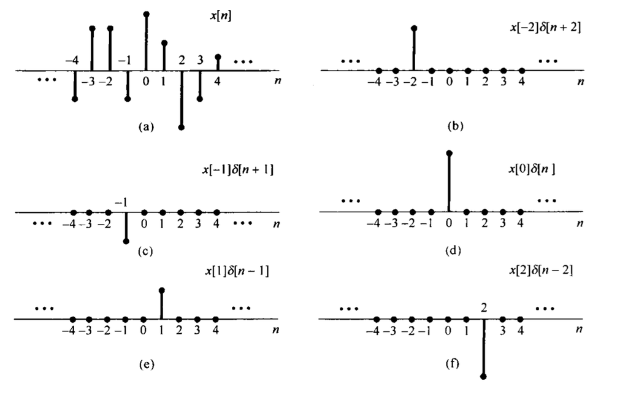

## 离散时间线性系统的单位脉冲响应与卷积和表示

令$h_{k}=T\left(\tau_{k} \delta\right)$ 代表线性时不变系统对移位脉冲（$\tau_{k} \delta$）的响应 ：

$$y=T(x)=T\left(\sum_{k=-\infty}^{\infty} x[k] \tau_{k} \delta\right)=\sum_{k=-\infty}^{\infty} x[k] T\left(\tau_{k} \delta\right)=\sum_{k=-\infty}^{\infty} x[k] h_{k}$$

一般情况下, 不同的 $k$对应的$h_{k}$ 之间彼此无关。

$$\begin{gathered}
h=T(\delta) \\
\text { 时不变性 } \Longrightarrow h_{k}=T\left(\tau_{k} \delta\right)=\tau_{k}(T(\delta))=\tau_{k} h = h[n-k]
\end{gathered}$$
其中，$h[n]=h_0[n]$定义为为**单位脉冲的序列响应**。

这个结果称为**卷积和**或者**叠加和**。

LTI 系统的响应——卷积和

$$y=\sum_{k=-\infty}^{\infty} x[k] \tau_{k} h, \quad \text { or } \quad y[n]=\sum_{k=-\infty}^{\infty} x[k] h[n-k], \forall n \in \mathbb{Z}$$

离散LTI 系统完全由单位脉冲响应刻画！

反之， 若给定$h(n)$, 系统 $T(x) \triangleq \sum_{k=-\infty}^{\infty} x[k] \tau_{k} h$ 也是线性时不变的。

## 离散时间线性系统的单位脉冲响应与卷积和表示

例：

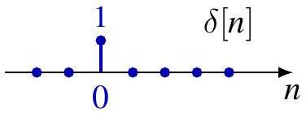

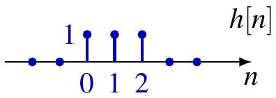

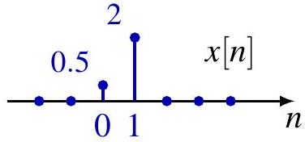

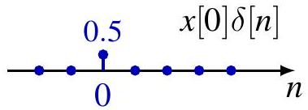

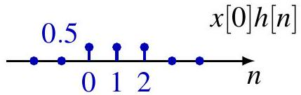

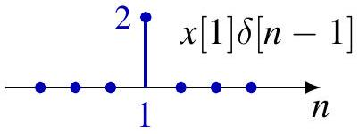

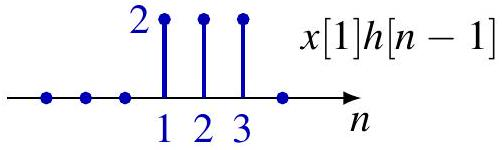

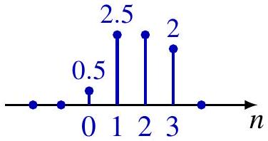

上述过程可以看作是在$k$时刻$x[k]$作用下，$h[n]$系统的所有时刻响应，然后把所有的$x[k]$作用下的响应叠加起来就是系统的最终输出。（线性系统的叠加性）。

## 离散时间线性系统的单位脉冲响应与卷积和表示

还是这个例子，换个视角，用反转-移位的方法做：

序列 $h[n-k]$ 看成固定 $n$ 时 $k$ 的函数，$h[n-k]$ 是单位脉冲响应 $h[k]$ 的时间反转与移位(思考一下物理意义)。

$$y[0]=\sum_{k=-\infty}^{\infty} x[k] h[0-k]=0.5$$

序列 $x[k]$ 与序列 $h[1-k]$ 的乘积有两个非零样本，相加之后得

$$y[1]=\sum_{k=-\infty}^{\infty} x[k] h[1-k]=0.5+2.0=2.5$$

$$y[2]=\sum_{k=-\infty}^{\infty} x[k] h[2-k]=0.5+2.0=2.5$$

$$y[3]=\sum_{k=-\infty}^{\infty} x[k] h[3-k]=2.0$$

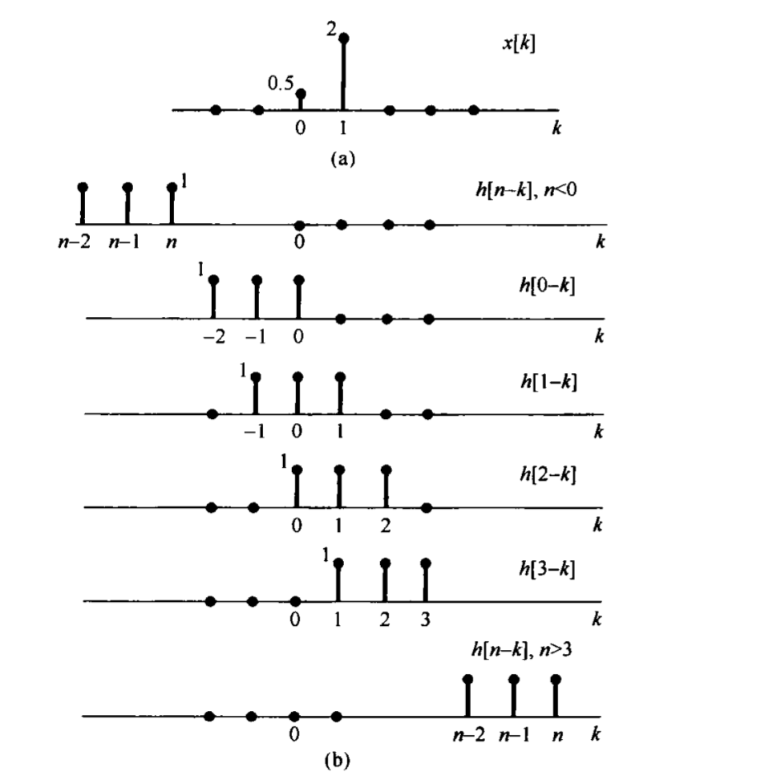

系统在$n$时刻的总输出$y[n]$由历史上各个时刻的有效因果输入激励$x[k]$的响应累加获得！

## 简单 LTI 系统的冲激响应

恒等系统

$$h[n]=\delta[n]$$

比例（标量）放大

$$h[n]=K \delta[n]$$

时移

$$h[n]=\delta_{a}[n] \triangleq \delta[n-a]$$

累加器

$$h[n]=\sum_{k=-\infty}^{n} \delta[k]=u[n]$$

一阶差分

$$h[n]=\delta[n]-\delta[n-1]$$

## 卷积的计算方法

1. **绘制信号**

   将 $x_{1}$ 和 $x_{2}$ 表示为自变量 $k$ 的函数，即绘制$x_{1}[k], \quad x_{2}[k]$
2. **信号反转（序列翻转）**

   将 $x_{2}$ 关于原点反转，得到 $R x_{2}$，即$R x_{2} = x_{2}[-k]$
3. **序列平移**

   对于给定的 $n$，将 $R x_{2}$ 向右平移 $n$，得到$\tau_{n}(R x_{2}) = x_{2}[n-k]$
4. **逐点相乘**

   将 $x_{1}$ 与 $\tau_{n}(R x_{2})$ 按分量逐点相乘，得到序列$g_{n} = x_{1} \cdot \tau_{n}(R x_{2})$，即

   $$g_{n}[k] = x_{1}[k]\,x_{2}[n-k]$$
5. **求和得到卷积结果**

   对 $g_{n}$ 关于 $k$ 求和，得到离散卷积

   $$(x_{1} * x_{2})[n]
   =
   \sum_{k=-\infty}^{\infty} g_{n}[k]$$
6. **对每个 $n$ 重复上述步骤**： 对不同的 $n$ 重复步骤 1–5，即可得到完整的卷积序列 $(x_{1} * x_{2})[n]$。

## 卷积示例1

例： 已知 $x[n]=\alpha^{n} u[n]$ 和 $h[n]=u[n]$ ，其中$\alpha \in(0,1)$.

对于 $n<0$,

$$(x * h)[n]=0$$

对于 $n \geq 0$,

$$(x * h)[n]=\sum_{k=0}^{n} \alpha^{k}=\frac{1-\alpha^{n+1}}{1-\alpha}$$

因此

$$(x * h)[n]=\left(\frac{1-\alpha^{n+1}}{1-\alpha}\right) u[n]$$

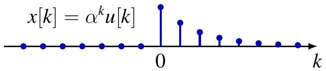

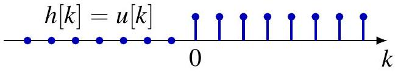

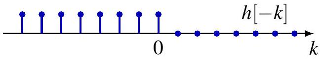

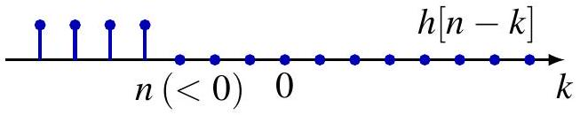

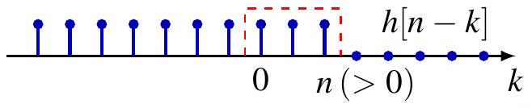

## 卷积示例2 （直接计算）

例： 已知 $x[n]=\alpha^{n} u[n]$ 和 $h[n]=u[n]$， 其中 $\alpha \in(0,1)$.

$$\begin{aligned}
(x * h)[n] & =\sum_{k=-\infty}^{\infty} x[k] h[n-k] \\
& =\sum_{k=-\infty}^{\infty} \alpha^{k} u[k] u[n-k] \\
& =\sum_{0 \leq k \leq n} \alpha^{k} \\
& =u[n] \sum_{k=0}^{n} \alpha^{k} \\
& =\left(\frac{1-\alpha^{n+1}}{1-\alpha}\right) u[n]
\end{aligned}$$

对$\alpha>1$也成立

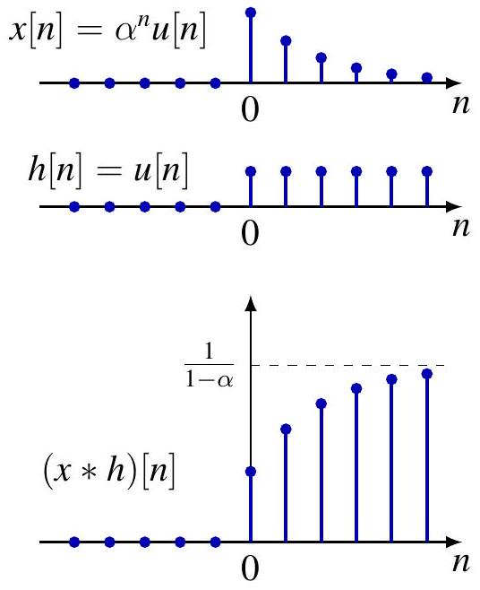

## 卷积示例3

例： 已知

$$\begin{aligned}
& x[n]= \begin{cases}1, & 0 \leq n \leq 4 \\
0, & \text { 其他 }\end{cases} \\
& h[n]= \begin{cases}\alpha^{n}, & \alpha > 1, 0 \leq n \leq 6 \\
0, & \text { 其他 }\end{cases}
\end{aligned}$$

5种情况：

- $n < 0$: $y[n] = 0$（无重叠）
- $0 \le n \le 4$: $y[n] = \sum_{k=0}^{n} \alpha^{n-k} = \frac{1-\alpha^{n+1}}{1-\alpha}$
- $4 < n \le 6$: $y[n] = \sum_{k=0}^{4} \alpha^{n-k} = \alpha^{n-4} \frac{1-\alpha^5}{1-\alpha}$
- $6 < n \le 10$: $y[n] = \sum_{k=n-6}^{4} \alpha^{n-k} = \frac{\alpha^{n-4}-\alpha^7}{1-\alpha}$
- $n > 10$: $y[n] = 0$（完全移出）

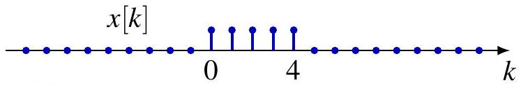

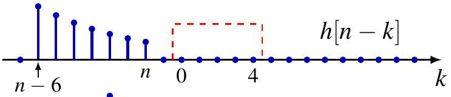

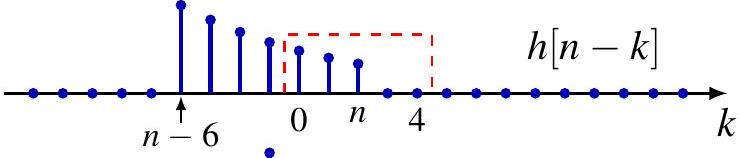

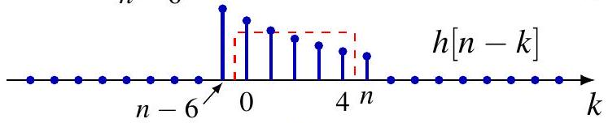

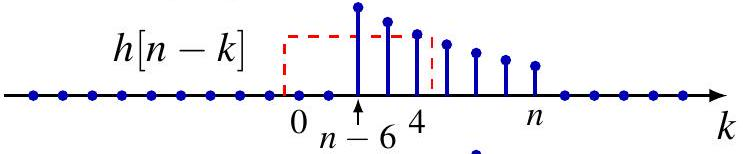

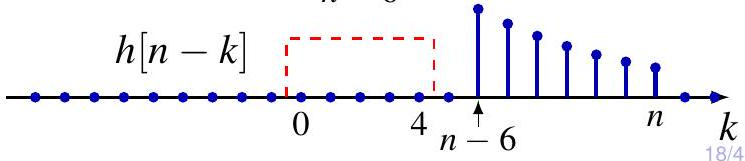

返回目录

## 目录

- 离散时间线性时不变系统
  - 用脉冲表示离散时间信号
  - 离散时间线性时不变系统的单位脉冲响应及卷积和表示
- **连续时间线性时不变系统**
  - 用冲激表示连续时间信号
  - 连续时间线性时不变系统的单位冲激响应及卷积和表示
- 线性时不变系统的性质
  - 线性时不变系统的交换律、分配律与结合律
  - 线性时不变系统的记忆性、可逆性、因果性和稳定性
  - 线性时不变系统的单位阶跃响应
- 用微分方程和差分方程描述的因果线性时不变系统
  - 线性常系数微分方程
  - 线性常系数差分方程
  - 一阶系统的方框图表示
- 奇异函数

# 连续时间线性时不变系统

## 连续时间信号的冲激表示

连续时间单位冲激的抽样（筛选）性质

考虑用一串脉冲或阶梯信号 $\hat{x}(t)$ 来近似 $x(t)$。如同离散时间情况一样，对于近似式 $\hat{x}(t)$ 来说，可以用一串延时脉冲的线性组合来表示，若定义

$$\delta_{\Delta}(t)= \begin{cases}\frac{1}{\Delta}, & 0 \leqslant t<\Delta \\ 0, & \text { 其他 }\end{cases}$$

由于 $\Delta \delta_{\Delta}(t)$ 为 1 ，则 $\hat{x}(t)$ 可表示成

$$\hat{x}(t)=\sum_{k=-\infty}^{\infty} x(k \Delta) \delta_{\Delta}(t-k \Delta) \Delta$$

当 $\Delta \rightarrow 0$时：

$$x(t)=\int_{-\infty}^{+\infty} x(\tau) \delta(t-\tau) \mathrm{d} \tau$$

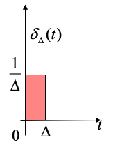

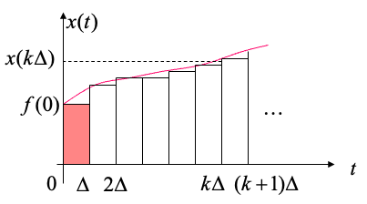

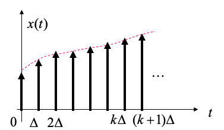

$x(t)$实际上是移位冲激的**加权“和”(积分)**。

## 连续时间线性时不变系统的单位冲激响应及卷积和表示

线性系统信号$x(t)$的响应 $\hat{y}(t)$ 就是系统对 $\delta_{\Delta}(t)$ 加权和移位脉冲响应的叠加。

令 $\hat{h}_{k \Delta}(t)$ 为一个线性时不变系统对输人 $\delta_{\Delta}(t-k \Delta)$ 的响应，根据**叠加性质**，对连续时间线性系统:

$$\hat{y}(t)=\sum_{k=-\infty}^{+\infty} x(k \Delta) \hat{h}_{k \Delta}(t) \Delta$$

其中

$\hat{h}_{k \Delta}=T\left(\tau_{k \Delta} p_{\Delta}\right)$ 是移位冲激响应 。

- $\hat{x}_{\Delta} \rightarrow x$ 和 $\hat{y}_{\Delta} \rightarrow y=T(x)$
- 对于 $k \Delta \rightarrow \tau$, 有 $\hat{h}_{k \Delta} \rightarrow h_{\tau}=T\left(\delta_{\tau}\right)$

那么：$y(t)=\lim _{\Delta \rightarrow 0} \sum_{k=-\infty}^{+\infty} x(k \Delta) \hat{h}_{k \Delta}(t) \Delta$

当 $\Delta \rightarrow 0$时：

$$y(t)=\int_{-\infty}^{+\infty} x(\tau) h_\tau(t) \mathrm{d} \tau$$

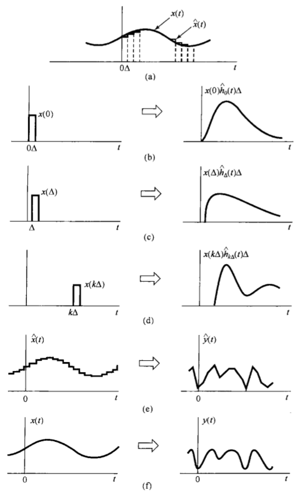

## 连续时间线性时不变（LTI）系统

单位冲激响应

$$\begin{gathered}
h(t)=h=h_{0}=T(\delta) \\
\text { 时不变性 } \Longrightarrow h_{\tau}=T\left(\delta_{\tau}\right)=\tau_{\tau}(T(\delta))=\tau_{\tau} h
\end{gathered}$$

LTI 系统的响应——**卷积积分**

$$y(t)=\int_{-\infty}^{+\infty} x(\tau) h(t-\tau) d \tau$$

LTI 系统完全由**单位冲激响应刻画**！

反之 给定$h(t)$, 系统

$$T(x)(t) \triangleq \int_{-\infty}^{+\infty} x(\tau) h(t-\tau) d \tau$$
也是线性时不变的(LTI)。

## 简单 LTI 系统的冲激响应

恒等系统
$$h(t)=\delta(t)$$

比例（标量）放大

$$h(t)=K \delta(t)$$

时移

$$h(t)=\delta_{a}(t) \triangleq \delta(t-a)$$

积分器

$$h(t)=\int_{-\infty}^{t} \delta(\tau) d \tau=u(t)$$

卷积

$$\left(x_{1} * x_{2}\right)(t)=\int_{-\infty}^{+\infty} x_{1}(\tau) x_{2}(t-\tau) d \tau$$

## 卷积的计算方法

1. **绘制信号**

   将 $x_{1}$ 和 $x_{2}$ 表示为自变量 $\tau$ 的函数，即绘制$x_{1}(\tau), \quad x_{2}(\tau)$
2. **信号反转（时间反转）**

   将 $x_{2}(\tau)$ 关于原点反转，得到$x_{2}(-\tau)$
3. **信号平移**

   对于给定的 $t$，将 $x_{2}(-\tau)$ 向右平移 $t$，得到$x_{2}(t-\tau)$
4. **逐点相乘**

   将 $x_{1}(\tau)$ 与 $x_{2}(t-\tau)$ 逐点相乘，得到函数

   $$g_t(\tau) = x_{1}(\tau)x_{2}(t-\tau)$$
5. **积分得到卷积结果**

   对 $g_t(\tau)$ 关于 $\tau$ 积分，得到卷积结果

   $$(x_{1} * x_{2})(t)
   =
   \int_{-\infty}^{\infty}
   x_{1}(\tau)x_{2}(t-\tau)\, d\tau$$
6. 对于每个$t$，重复 $1-5$

## 卷积示例1

例：令 $x(t)=e^{-a t} u(t)$ 以及 $h(t)=u(t)$，设 $a>0$.

对于 $t<0$,

$$(x * h)(t)=0$$

对于 $t \geq 0$,

$$(x * h)(t)=\int_{0}^{t} e^{-a \tau} d \tau=\frac{1-e^{-a t}}{a}$$

因此

$$(x * h)(t)=\left(\frac{1-e^{-a t}}{a}\right) u(t)$$

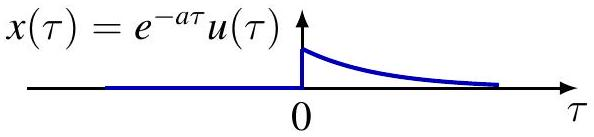

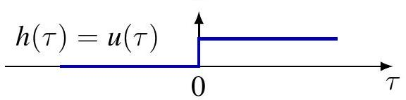

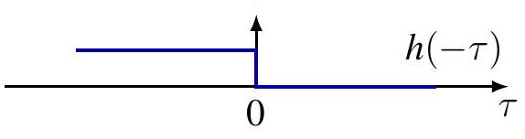

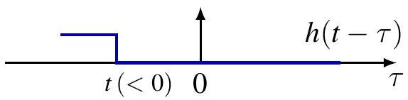

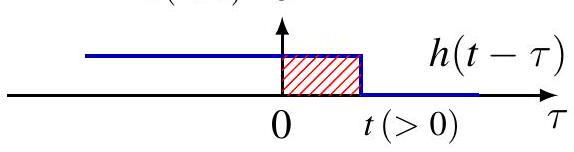